# **MTHM017 - Advanced Topics in Statistics, Assignment**

James R Lewis

00-00-2025

**Declaration of AI Assistance**: I have used OpenAI’s ChatGPT tool in creating this report.

AI-supported/AI-integrated use is permitted in this assessment. I acknowledge the following uses of GenAI tools in this assessment:

1. I have used GenAI tools to check and debug my code.
2. I have used GenAI tools to proofread and correct grammar or spelling errors.
3. I have used GenAI tools to give me feedback on a draft.

I declare that I have referenced use of GenAI outputs within my assessment in line with the University referencing guidelines.

# A. Bayesian Inference

## 1.

[6 marks] Read in the data, then for each person produce a histogram of that given person’s reaction times. The range of the x axis should be the same on each histogram. Visually compare the reaction time distributions of schizophrenic and non-schizophrenic individuals. What differences/similarities can you observe? Reference the histograms of specific individuals to support your conclusions.

I will begin by making the dataset more usable and clear.

```r
# Renaming first column
names(rtimes)[1] <- "PatientType"
# Classifying the patient type, 1-11 non-schiz, 12-17 schiz
rtimes$PatientType <- c(rep("non-schizophrenic", 11), rep("schizophrenic", 6))
rtimes1 <- rtimes
head(rtimes1)
```

```
##         PatientType  T1  T2  T3  T4  T5  T6  T7  T8  T9 T10 T11 T12 T13 T14 T15
## 1 non-schizophrenic 312 272 350 286 268 328 298 356 292 308 296 372 396 402 280
## 2 non-schizophrenic 354 346 384 342 302 312 322 376 306 402 320 298 308 414 304
## 3 non-schizophrenic 256 284 320 274 324 268 370 430 314 312 362 256 342 388 302
## 4 non-schizophrenic 260 294 306 292 264 290 272 268 344 362 330 280 354 320 334
## 5 non-schizophrenic 204 272 250 260 314 308 246 236 208 268 272 264 308 236 238
## 6 non-schizophrenic 590 312 286 310 778 364 318 316 316 298 344 262 274 330 312
##   T16 T17 T18 T19 T20 T21 T22 T23 T24 T25 T26 T27 T28 T29 T30
## 1 330 254 282 350 328 332 308 292 258 340 242 306 328 294 272
## 2 422 388 422 426 338 332 426 478 372 392 374 430 388 354 368
## 3 366 298 396 274 226 328 274 258 220 236 272 322 284 274 356
## 4 276 418 288 338 350 350 324 286 322 280 256 218 256 220 356
## 5 350 272 252 252 236 306 238 350 206 260 280 274 318 268 210
## 6 310 376 326 346 334 282 292 282 300 290 302 300 306 294 444
```

### Creating Histograms

We want to extract the data from these columns **rtimes[, 2:31]**, for all 17 patients. We will plot 17 histograms, displaying the distribution of the 30 reaction times.

In order to keep a consistent range across the 17 histograms, we need to find the absolute minimum and maximum values in this dataset. To do this, we extract all the data, 17 rows * 30 trials.

```r
DataValues <- unlist(rtimes1[, 2:31])
range(DataValues)
```

```
## [1]  204 1714
```

```r
# We want to store these values

x_min <- 204
x_max <- 1714
```

Below, we can observe two sets of histograms, the first containing the eleven non-schizophrenic patients, and the seconds containing the 6 schizophrenic patients.

We reshape to data frame to long format, as having the reaction time data in one column (a list) makes much easier to code the histogram. To create a separate plot for each patient, we use facet_wrap() to group data by PatientID.

```r
# Reshaping to long format
rtimes_long <- rtimes1 %>%
  pivot_longer(cols = starts_with("T"),  # Columns T1 to T30
               names_to = "Trial",
               values_to = "ReactionTime") %>%
  mutate(PatientID = rep(1:17, each = 30)) %>%  # Add patientID
  select(PatientID, PatientType, ReactionTime)

# Splitting into two datasets so I can have seperate histogramws
non_schizo <- rtimes_long %>% filter(PatientType == "non-schizophrenic")
schizo <- rtimes_long %>% filter(PatientType == "schizophrenic")
```

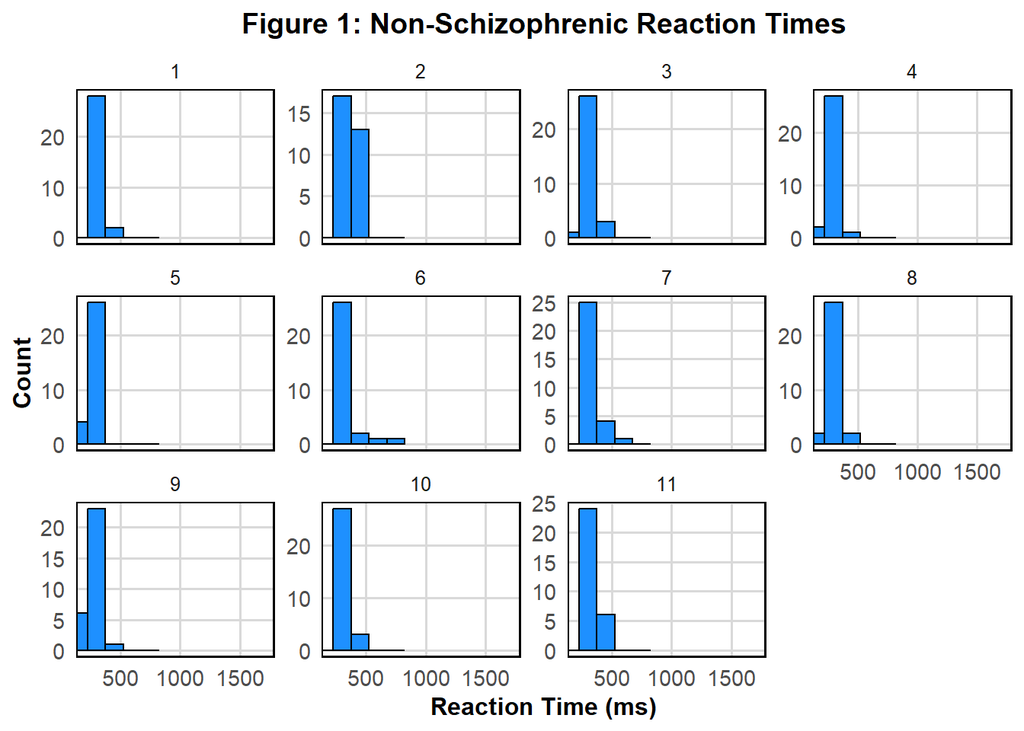

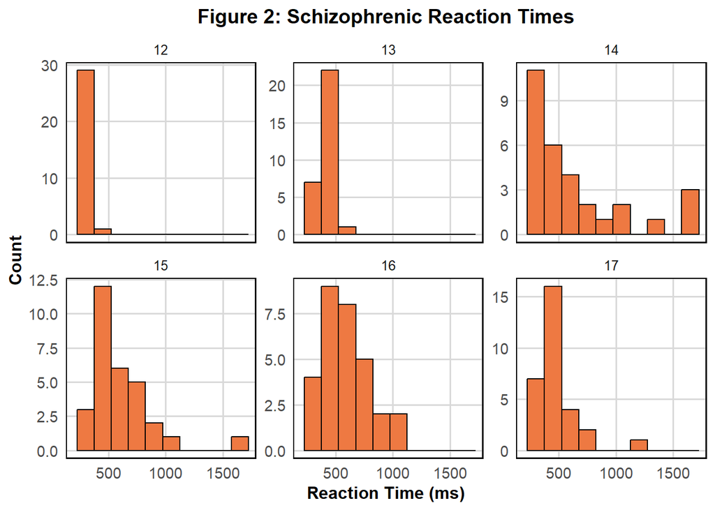

```r
# Plotting non-schizophrenic histograms
hist1 <- ggplot(non_schizo, aes(x = ReactionTime)) +
  geom_histogram(binwidth = 150, fill = "dodgerblue1", color = "black") +
  facet_wrap(~ PatientID, ncol = 4, scales = "free_y") +  # 11 plots, 4 columns
  coord_cartesian(xlim = c(x_min, x_max)) +  # Fixed x-axis
  labs(title = "Figure 1: Non-Schizophrenic Reaction Times",
       x = "Reaction Time (ms)",
       y = "Count") +
  custom_theme

# Plotting schizophrenic histograms
hist2 <- ggplot(schizo, aes(x = ReactionTime)) +
  geom_histogram(binwidth = 150, fill = "sienna2", color = "black") +
  facet_wrap(~ PatientID, ncol = 3, scales = "free_y") +  # 6 plots, 3 columns
  coord_cartesian(xlim = c(x_min, x_max)) +  # Fixed x-axis
  labs(title = "Figure 2: Schizophrenic Reaction Times",
       x = "Reaction Time (ms)",
       y = "Count") +
  custom_theme
```

In contrast, the Schizophrenic patients histograms in Figure 2 exhibit a much wider spread of reaction times, with some patients having reactions times exceeding 1500ms. This indicates greater variability, for instance, patient 14 has a wide range of reaction times with many being greater than 1000ms, whilst also having a significant count below 500ms. This suggests that Schizophrenic patients have a mixture of normal and delayed responses, and this aligns with the theory of attention deficits and motor retardation in schizophrenics. This is generally observed by their inconsistent distributions and right skew, compared to the tighter uniform distributions of non-schizophrenics

Nonetheless, both groups share similarities in their distributions. They both have peaks within the first two bins 0-500ms, as you can see when comparing patient 8 (non) to 13 (schizophrenic). However, only schizophrenics have reaction time values in the higher bands (greater than 800ms)

Overall, these histograms support the hypothesis that schizophrenics experience attention deficits and motor reflex retardation, as seen by the wider spread of values and more irregular histograms for schizophrenic individuals.

logarithm is necessary here (referencing the relevant output), then perform the transformation yourself. For each person compute the standard deviation of the log transformed reaction times of that individual.

-Calculate standard deviations: For each of the 17 people, compute the standard deviation of their 30 log-transformed reaction times.

Log-transforming the reaction times is necessary for the model above for two main reasons. Firstly, there is skewness in the data as seen in the Schizophrenic reaction times histograms, for example, Patient 14 and 15 are right-skewed distributions with extreme values (over 1500ms), whilst non-schizophrenic’s have a tighter distribution. Following this, schizophrenics don’t seems to follow a normal distribution, thus, log transforming reduces the skewness and helps stabilise the variance from the effect of outliers/skew. This enambles the data to fit the models normal distributions assumption better. Finally, the log-transformation scales the data, making the mean and variance more interpretable. For example, the original range of 204ms to 1714ms, becomes 5.31 to 7.44 (3 s.f.) when log-transformed. Put simply, handling smaller numbers is easier.

```r
log_rtimes_long <- rtimes_long %>%
  mutate(LogReactionTime = log(ReactionTime))
range(log_rtimes_long$LogReactionTime)
```

```
## [1] 5.318120 7.446585
```

```r
# checking the range also lets us knowif any observations are negative.
```

Now we compute the standard deviation of each patients 30 log-transformed reaction times. This is useful as it measures the within personal variability on the log scale.

```r
# Compute standard deviation of log-transformed reaction times for each person
sd_log <- log_rtimes_long %>%
  group_by(PatientID) %>%
  summarise(SD_Log_RT = sd(LogReactionTime))

# Print results
head(sd_log)
```

```
## # A tibble: 6 × 2
##   PatientID SD_Log_RT
##       <int>     <dbl>
## 1         1     0.127
## 2         2     0.129
## 3         3     0.169
## 4         4     0.150
## 5         5     0.145
## 6         6     0.224
```

## 3. [5 marks] List the parameters of the model and assign non-informative uniform prior distributions to each parameter, paying attention to the values these parameters are allowed take.

The reason we are using non-informative uniform prior distributions is because we lack prior knowledge about the parameters. Thus, having a reasonable range of values that are equally likely gives a non-bias estimation and allows the data to strong influence the posterior distribution.

**Parameters and Priors:**

## **For Non-Schizophrenic Individuals:**

- $\alpha_i$ (for $i = 1$ to 17): Person-specific means on the log scale.

```r
alpha[i] ~ dunif(0, 10)
```

- $\mu$: Mean of $\alpha_i$ for non-schizophrenics, which represents the mean log reaction time. with most values between 200ms and 1800ms), when log transformed they equal, 5.3 and 7.5.. A wide range of -10 - 10 to avoid bias and cover potential outliers.

```r
mu ~ dunif(-10, 10)
```

```r
sigma_y2 ~ dunif(0, 5)
# tau_y <- 1 / sigma_y2
```

```r
sigma_alpha2 ~ dunif(0, 5)
# tau_alpha <- 1 / sigma_alpha2
```

**For Schizophrenic Individuals:**

```r
beta ~ dunif(0, 10)
```

- $\tau$: Log-transformed delay parameter for schizophrenics ($\tau > 0$). This is a wide range, but remains uninformative and is contrained to positive values.

```r
tau ~ dunif(0, 10)
```

- $\lambda$: Probability of delay ($0 \leq \lambda \leq 1$). Value must lie between 0 and 1, as $\lambda$ is a probability.

```r
lambda ~ dunif(0, 1)
```

## 4.

First we need to create a data matrix which JAGS can process. We extracting the raw reaction times in the original wide format, and then Log-transforming them. After this, we can create our data list for our JAGS model. Defining separate matrixs for Schizophrenic and non-Schizophrenic reaction times, the number of patients in each group, and the number of trials. It is important to define these now, as we call upon them in the model definition.

```r
extractedRtimes <- rtimes[, 2:31]
log_rtimes <- log(extractedRtimes)

data_list <- list(
  y.ns = log_rtimes[1:11, ],  # Non-schizophrenic reaction times (11 x 30)
  y.s = log_rtimes[12:17, ],  # Schizophrenic reaction times (6 x 30)
  N_ns = 11,                  # Number of non-schizophrenics
  N_s = 6,                    # Number of schizophrenics
  T = 30                      # Number of trials
)
```

### **Model Specification**

Now we define the hierarchical Bayesian model. The model is account for the two groups of patients, their individual variability.

**Reaction times for Non-Schizophrenic patients (N.S)** ($i$th individual) are modeled as:

Individuals **mean** ($\alpha_i$) reaction time is:
$$\alpha_i \sim N(\mu, \sigma_\alpha^2), \quad i =
1, 2, \ldots, 11$$
- $\mu$ is the mean reaction time for N.S - $\sigma_\alpha^2$ is the intragroup variance in reaction times

**Reaction times for Schizophrenic patients (S)**

$$y_{ij} \sim N(\alpha_i + \tau z_{ij},
\sigma_y^2) \quad i = 12, 13, \ldots, 17, \quad j = 1, 2, \ldots,
30$$
Where: - $\tau$ is the extra delay - $\z_{ij}$ is an indicator (one or zero)

$$z_{ij} \sim \text{Bernoulli}(\lambda),
\quad i = 12, 13, \ldots, 17, \quad j = 1, 2, \ldots, 30$$
Schizophrenic patients can have delayed responses due to attention deficit. This is modeled through the above Bernoulli distributed indicator function. $\lambda$ is the probability of a trial being delayed.

Schizophrenics mean reaction time:
$$\alpha_i \sim N(\mu + \beta, \sigma_\alpha^2),
\quad i = 12, 13, \ldots, 17$$
Where: - $\beta$ is the increase in mean reaction time for S

### **Defining the JAGS Model**

```r
jags.model <- function(){
    # Reaction time of non-schizophrenics
    for (i in 1:N_ns){
        for (j in 1:T) {
            y.ns[i,j] ~ dnorm(alpha.ns[i], p.y)
        }
        alpha.ns[i] ~ dnorm(mu, p.alpha)
    }

    # Reaction time of schizophrenics
     for (i in 1:N_s){
        for (j in 1:T) {
            z[i,j] ~ dbern(lambda)  # Bernoulli for delay indicator
            y.s[i,j] ~ dnorm(alpha.s[i] + tau * z[i,j], p.y) # Corrected indexing
        }
        alpha.s[i] ~ dnorm(mu + beta, p.alpha)
    }

    # Priors
    mu ~ dunif(-10, 10) # Mean for non-schizophrenics
    sigma_y2 ~ dunif(0.001, 5) # Avoiding exact 0 for stability
    sigma_alpha2 ~ dunif(0.001, 5) # Avoiding exact 0 for stability
    beta ~ dunif(0, 10) # Schizophrenics should have longer reaction times
    tau ~ dunif(0, 10) # Delay parameter
    lambda ~ dunif(0, 1) # Probability of delay

    # Precision parameters
    p.y <- 1 / sigma_y2
    p.alpha <- 1 / sigma_alpha2
}
```

### **Defining the Parameters, what we what to track, and initial values**

```r
 jags.param <- c("mu", "beta", "tau", "lambda", "p.y", "p.alpha", "alpha.ns", "alpha.s", "sigma_y2")


inits1 <- list(
    mu = 5, beta = 1, tau = 1, lambda = 0.5,
    sigma_y2 = 1, sigma_alpha2 = 1,
    z = matrix(0, nrow = 6, ncol = 30)
)
inits2 <- list(
    mu = 6, beta = 4, tau = 5, lambda = 0.3,
    sigma_y2 = 2, sigma_alpha2 = 2,
    z = matrix(0, nrow = 6, ncol = 30)
)
jags.inits <- list(inits1, inits2)
```

### **Fitting the JAGS Model**

In the first JAGS model, we are running two MCMC chains, with 10000 iterations and discarding the first 5000 iterations to view the convergence. We are also computing the Deviance Information Criterion (DIC), so we can compare this model to future ones later.

```r
 jags.mod.fit <- jags(data = data_list, inits = jags.inits,
  parameters.to.save = jags.param, n.chains = 2, n.iter = 10000,
  n.burnin = 5000, n.thin = 1 , model.file = jags.model, DIC = TRUE)
```

```
## module glm loaded
```

## 5. Monte Carlo Marcov Chain

```r
jagsfit.mcmc <- as.mcmc(jags.mod.fit)
 MCMCtrace(jagsfit.mcmc,type = 'trace',ind = TRUE, pdf = FALSE)
```

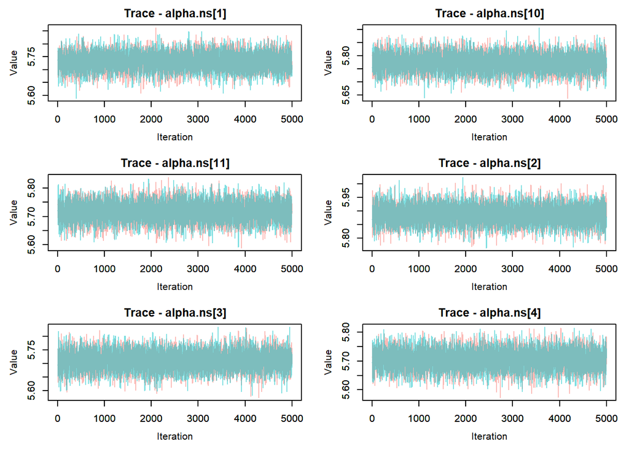

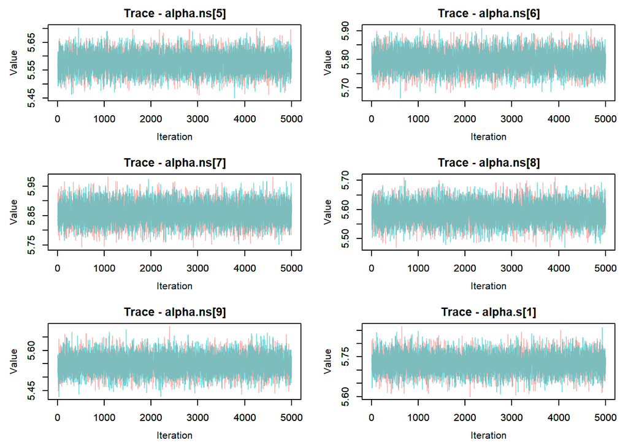

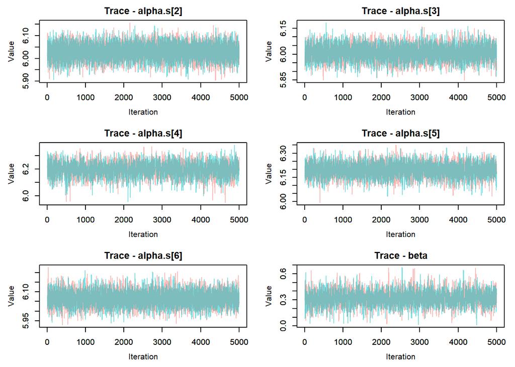

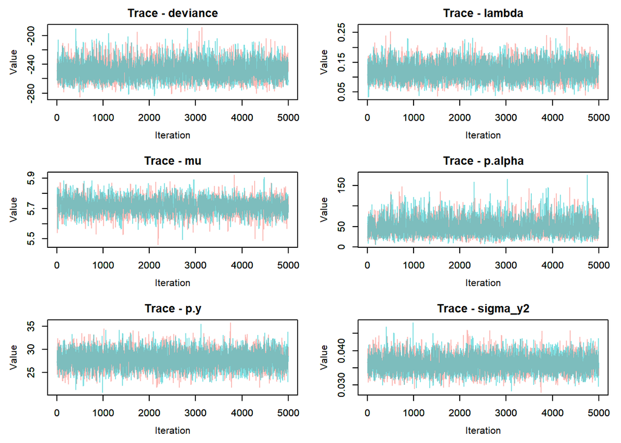

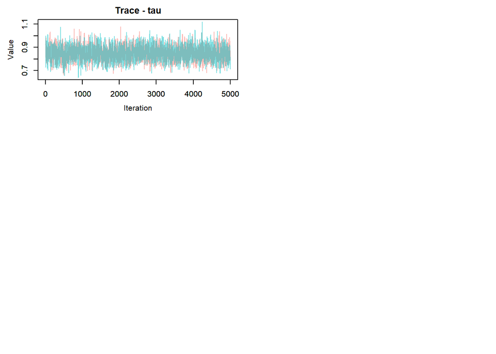

To check for convergence more accurately, we can extract the Gelman-Rubin test statistic values. This is in the code below.

```r
gelman.diag(jagsfit.mcmc,multivariate=FALSE)
```

```
## Potential scale reduction factors:
##
##              Point est. Upper C.I.
## alpha.ns[1]           1       1.00
## alpha.ns[10]          1       1.00
## alpha.ns[11]          1       1.00
## alpha.ns[2]           1       1.00
## alpha.ns[3]           1       1.00
## alpha.ns[4]           1       1.00
## alpha.ns[5]           1       1.00
## alpha.ns[6]           1       1.00
## alpha.ns[7]           1       1.00
## alpha.ns[8]           1       1.00
## alpha.ns[9]           1       1.00
## alpha.s[1]            1       1.00
## alpha.s[2]            1       1.00
## alpha.s[3]            1       1.00
## alpha.s[4]            1       1.00
## alpha.s[5]            1       1.00
## alpha.s[6]            1       1.00
## beta                  1       1.01
## deviance              1       1.00
## lambda                1       1.00
## mu                    1       1.01
## p.alpha               1       1.00
## p.y                   1       1.00
## sigma_y2              1       1.00
## tau                   1       1.00
```

Since chains have converged, there is no need to update the model to draw new samples.

## 6. **Posterior Distributions**

[10 marks] The primary interest to psychologists lies in the parameters β, λ and τ. Plot the posterior distributions of these three parameters, then produce numerical summaries of the distributions. Check if you have enough samples for posterior inference. Remembering that the response time was modeled on the log scale (and therefore both τ and β are on the log scale), give the median and a 95% posterior interval for each of these parameters on their original scale. Based on these estimates what conclusions can you make about the reaction times of schizophrenics compared to non-schizophrenics?

First, we check to summary statistics.

```r
summary(jagsfit.mcmc)
```

[output not shown]

Now we extract the relevent statistics for Beta, Lamba and Tau. This can be seen in the code below.

### Beta

```r
pos_beta<-substr(rownames(jags.mod.fit$BUGSoutput$summary),1,4)=='beta'


# Extract posterior mean for mu
beta_mean<-jags.mod.fit$BUGSoutput$summary[pos_beta,1]
# Extract posterior median
beta_median<-jags.mod.fit$BUGSoutput$summary[pos_beta,5]

# Extract 2.5 percentile of the posterior
beta2.5 <- jags.mod.fit$BUGSoutput$summary[pos_beta,3]
# Extract97.5percentileoftheposterior
beta97.5 <- jags.mod.fit$BUGSoutput$summary[pos_beta,7]
```

### Lambda

```r
pos_lambda <- substr(rownames(jags.mod.fit$BUGSoutput$summary), 1, 6) == "lambda"
lambda_mean <- jags.mod.fit$BUGSoutput$summary[pos_lambda, 1]
lambda_median <- jags.mod.fit$BUGSoutput$summary[pos_lambda, 5]
lambda2.5 <- jags.mod.fit$BUGSoutput$summary[pos_lambda,3]
lambda97.5 <- jags.mod.fit$BUGSoutput$summary[pos_lambda,7]
```

### Tau

```r
pos_tau <- substr(rownames(jags.mod.fit$BUGSoutput$summary), 1, 3) == "tau"
tau_mean <- jags.mod.fit$BUGSoutput$summary[pos_tau, 1]
tau_median <- jags.mod.fit$BUGSoutput$summary[pos_tau, 5]
tau2.5 <- jags.mod.fit$BUGSoutput$summary[pos_tau,3]
tau97.5 <- jags.mod.fit$BUGSoutput$summary[pos_tau,7]
```

We add the summary statistics to a dataframe.

```r
df_stats <- data.frame(
  Parameter = c("Beta", "Lambda", "Tau"),
  Median = c(exp(beta_median), lambda_median, exp(tau_median)),
  Lower_95_CI = c(exp(beta2.5), lambda2.5, exp(tau2.5)),
  Upper_95_CI = c(exp(beta97.5), lambda97.5, exp(tau97.5))
)
```

```r
library(stargazer)
stargazer(df_stats, type = "text", summary = FALSE, title = "Reaction Time Parameters", digits = 3 )
```

```
##
## Reaction Time Parameters
## ==========================================
##   Parameter Median Lower_95_CI Upper_95_CI
## ------------------------------------------
## 1   Beta    1.376     1.170       1.631
## 2  Lambda   0.118     0.069       0.180
## 3    Tau    2.332     2.088       2.626
## ------------------------------------------
```